# Pendugaan Parameter, Diagnostik Model, dan Peramalan

Jonathan Marjono

## Packages

```r
library(ggplot2)
library(tsibble)
library(tseries)
library(MASS)
library(forecast)
library(TSA)
library(TTR)
library(aTSA)
library(graphics)
library(rio)
```

## Memasukkan Data Asli

Digunakan data produksi karet kering pada penugasan responsi 1 dan 5. Pada data ini terdapat sebanyak 120 periode.

```r
#Bersumber dari github
dtset <- import("https://raw.githubusercontent.com/jonathanmarjonoxz/MPDW/main/Responsi1/Data_ProduksiKaretKering.csv")
str(dtset)
```

```
## 'data.frame':    120 obs. of  2 variables:
##  $ Periode              : int  1 2 3 4 5 6 7 8 9 10 ...
##  $ Produksi Karet Kering: num  50 45.5 40.1 38.8 47.2 43.5 45.8 41.7 38.4 38.2 ...
```

```r
dim(dtset)
```

```
## [1] 120   2
```

```r
dtset.ts <- ts(dtset$`Produksi Karet Kering`) #Mengubah ke time series
```

## Eksplorasi Data

Sebelum masuk dalam tahap pemodelan, dilakukan eksplorasi data dengan plot deret waktu untuk melihat pola data yang ada.

### Plot Data Penuh

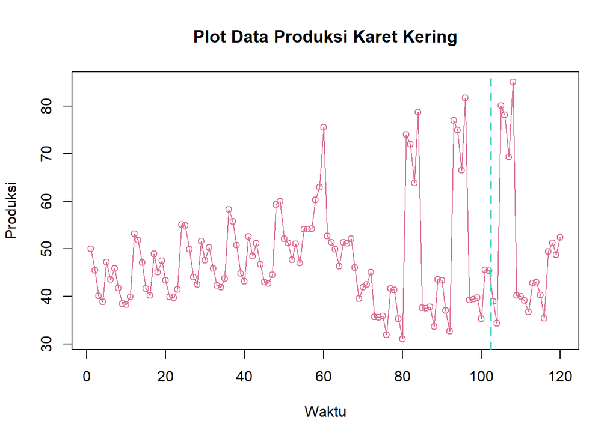

```r
#--PLOT TIME SERIES--#
plot.ts(dtset.ts, lty=1, lwd=1, type="o", xlab="Waktu", ylab="Produksi", main="Plot Data Produksi Karet Kering", col= "palevioletred")
abline(v=102.5, col="mediumturquoise", lty=2, lwd=2) #Garis pemisah train dan test
```

Berdasarkan plot data deret waktu di atas, terlihat bahwa data memiliki pola campuran yakni pola trend dengan musiman. Selain itu data cenderung stasioner dalam rataan, namun tidak dalam ragam. Selain itu untuk lebih memastikannya, akan dilakukan pengecekan stasioneritas data dengan plot ACF serta uji ADF. Berdasarkan pola data, pembagian data latih dan data uji ditetapkan dengan proporsi 85%:15%. Pada penugasan sebelumnya sudah dijelaskan bahwa data yang dipilih tidak terlalu baik, yang dapat dilihat pada pola sebaran datanya.

### Plot Data Latih

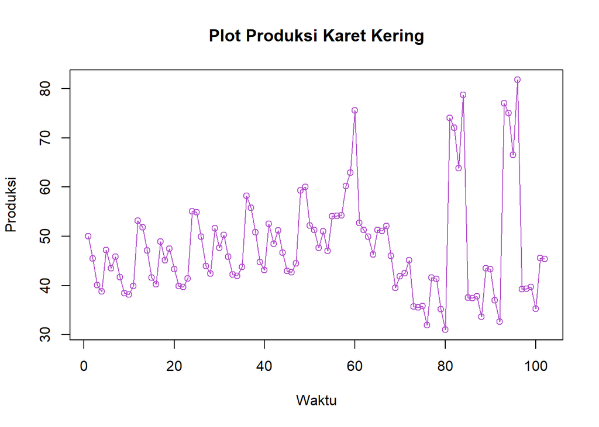

```r
#85% untuk data latih, yakni periode 1:102
dttrain <- dtset[1:102,]
train.ts <- ts(dttrain$`Produksi Karet Kering`)
plot.ts(train.ts, lty=1, lwd=1, type="o", xlab="Waktu", ylab="Produksi", main="Plot Produksi Karet Kering", col="mediumorchid3")
```

Berdasarkan plot data deret waktu pada data latih yang disajikan di atas, terlihat bahwa data bergerak pada nilai tengah tertentu, serta memiliki fluktuasi yang tinggi. Hal ini mengindikasikan bahwa data stasioner dalam rataan namun tidak dalam ragam.

### Plot Data Uji

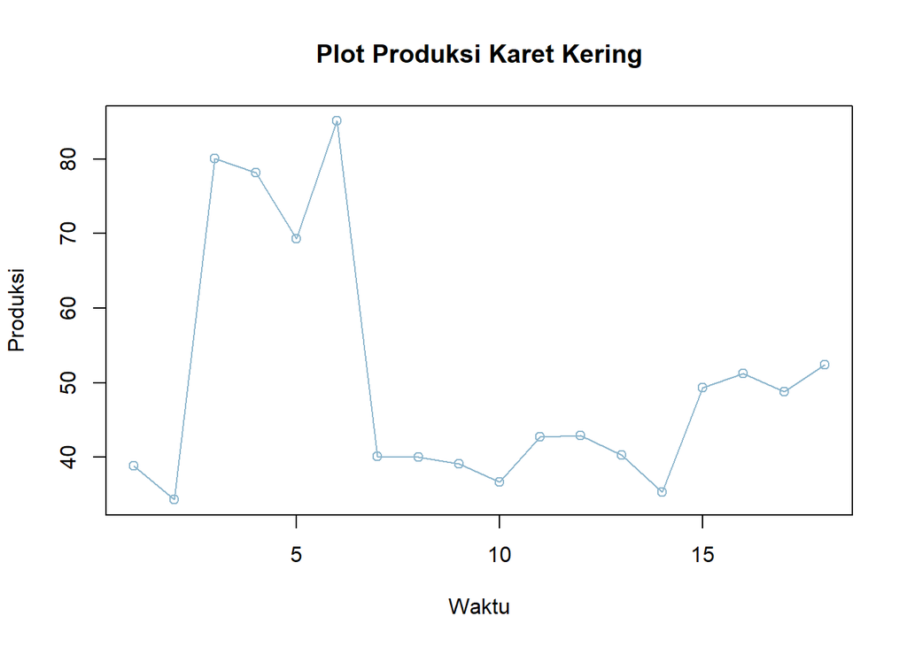

```r
#15% untuk data uji, yakni periode 103-120
dttest <- dtset[103:120,]
test.ts <- ts(dttest$`Produksi Karet Kering`)
plot.ts(test.ts, lty=1,lwd=1, type="o", xlab="Waktu", ylab="Produksi", main="Plot Produksi Karet Kering", col="lightskyblue3")
```

## Uji Stasioneritas Data

### Plot ACF

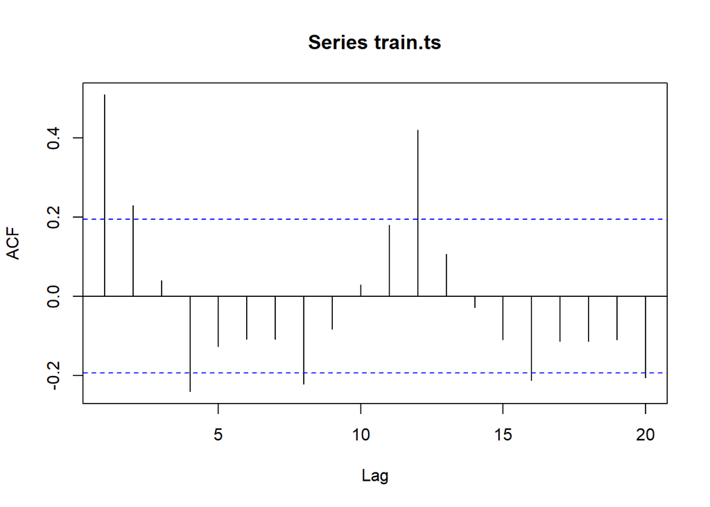

```r
#Memeriksa kestasioneran dengan ACF
acf(train.ts)
```

Berdasarkan plot ACF, terlihat bahwa plot ACF terjadi *cuts off* pada lag ke-2. Hal ini dapat memberikan indikasi bahwa data stasioner dalam rataan, sebab tidak menurun secara perlahan. Tentunya hal ini sesuai dengan hasil dari eksplorasi yang sebelumnya diperoleh.

### Uji ADF

```r
#Memeriksa kestasioneran dengan uji ADF
tseries::adf.test(train.ts)
```

```
##
##  Augmented Dickey-Fuller Test
##
## data:  train.ts
## Dickey-Fuller = -4.1087, Lag order = 4, p-value = 0.01
## alternative hypothesis: stationary
```

$H_0$ : Data tidak stasioner dalam rataan

$H_1$ : Data stasioner dalam rataan

Berdasarkan uji ADF tersebut, didapatkan nilai p-value sebesar 0.01 yang lebih kecil dari taraf nyata 5% sehingga tolak $H_0$. Hal ini menandakan bahwa data stasioner dalam rataan, serta sudah sesuai dengan hasil eksplorasi menggunakan plot time series dan plot ACF, sehingga dapat dinyatakan bahwa data tersebut stasioner dalam rataan.

### Plot Box-Cox

```r
index <- seq(1:102) #Sampai periode terakhir data train
bc = boxcox(train.ts~index, lambda = seq(-5,6,by=0.01))
```

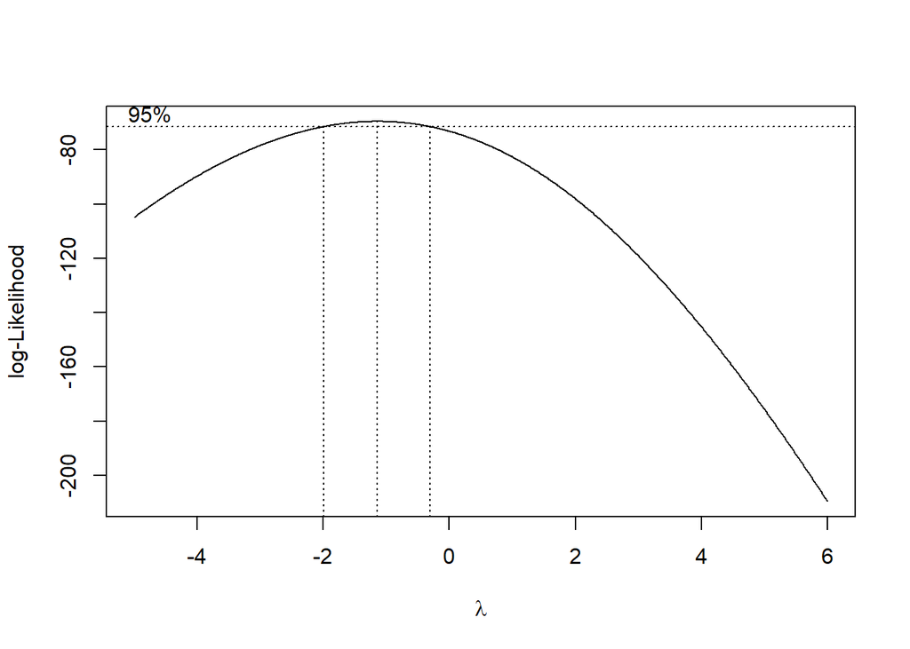

```r
#Nilai Rounded Lambda
lambda <- bc$x[which.max(bc$y)]
lambda
```

```
## [1] -1.14
```

```r
#SK
bc$x[bc$y > max(bc$y) - 1/2 * qchisq(.95,1)]
```

```
##   [1] -1.99 -1.98 -1.97 -1.96 -1.95 -1.94 -1.93 -1.92 -1.91 -1.90 -1.89 -1.88
##  [13] -1.87 -1.86 -1.85 -1.84 -1.83 -1.82 -1.81 -1.80 -1.79 -1.78 -1.77 -1.76
##  [25] -1.75 -1.74 -1.73 -1.72 -1.71 -1.70 -1.69 -1.68 -1.67 -1.66 -1.65 -1.64
##  [37] -1.63 -1.62 -1.61 -1.60 -1.59 -1.58 -1.57 -1.56 -1.55 -1.54 -1.53 -1.52
##  [49] -1.51 -1.50 -1.49 -1.48 -1.47 -1.46 -1.45 -1.44 -1.43 -1.42 -1.41 -1.40
##  [61] -1.39 -1.38 -1.37 -1.36 -1.35 -1.34 -1.33 -1.32 -1.31 -1.30 -1.29 -1.28
##  [73] -1.27 -1.26 -1.25 -1.24 -1.23 -1.22 -1.21 -1.20 -1.19 -1.18 -1.17 -1.16
##  [85] -1.15 -1.14 -1.13 -1.12 -1.11 -1.10 -1.09 -1.08 -1.07 -1.06 -1.05 -1.04
##  [97] -1.03 -1.02 -1.01 -1.00 -0.99 -0.98 -0.97 -0.96 -0.95 -0.94 -0.93 -0.92
## [109] -0.91 -0.90 -0.89 -0.88 -0.87 -0.86 -0.85 -0.84 -0.83 -0.82 -0.81 -0.80
## [121] -0.79 -0.78 -0.77 -0.76 -0.75 -0.74 -0.73 -0.72 -0.71 -0.70 -0.69 -0.68
## [133] -0.67 -0.66 -0.65 -0.64 -0.63 -0.62 -0.61 -0.60 -0.59 -0.58 -0.57 -0.56
## [145] -0.55 -0.54 -0.53 -0.52 -0.51 -0.50 -0.49 -0.48 -0.47 -0.46 -0.45 -0.44
## [157] -0.43 -0.42 -0.41 -0.40 -0.39 -0.38 -0.37 -0.36 -0.35 -0.34 -0.33 -0.32
## [169] -0.31
```

Plot Boxcox menunjukkan nilai rounded value ($\lambda$) optimum sebesar -1.14 dan pada selang kepercayaan 95% nilai memiliki batas bawah -1.99 serta batas atas -0.31. Selang tersebut tidak memuat nilai satu sehingga dapat dikatakan bahwa data tersebut tidak stasioner dalam ragam. Oleh karena itu, sebaiknya dilakukan penanganan berupa transformasi box-cox. Namun untuk penugasan kali ini tidak dilakukan, sebagaimana opsional.

## Identifikasi (Spesifikasi) Model

### Plot ACF

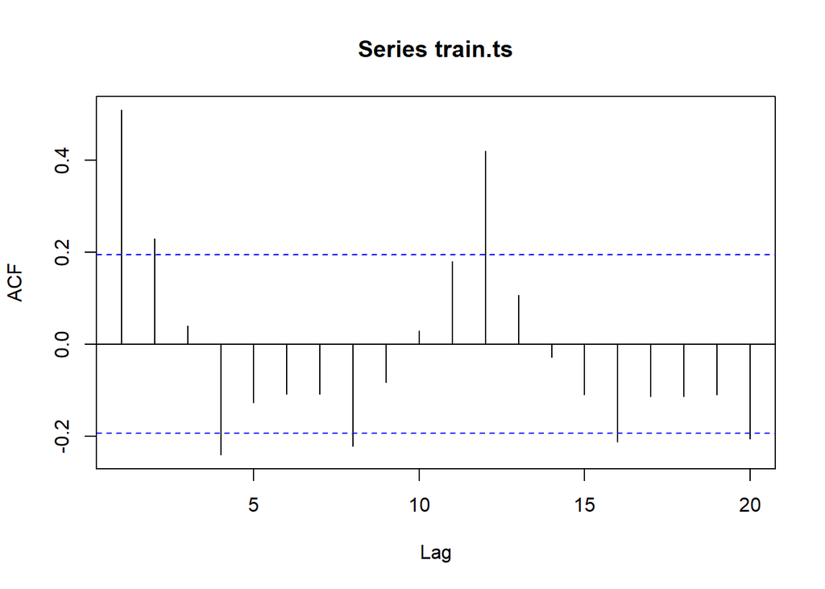

```r
acf(train.ts)
```

Berdasarkan plot tersebut, terlihat bahwa plot ACF cenderung *cuts off* pada lag kedua, sehingga plot PACF dianggap *tails off*, oleh karena itu model tentatifnya adalah ARIMA(0,0,2).

### Plot PACF

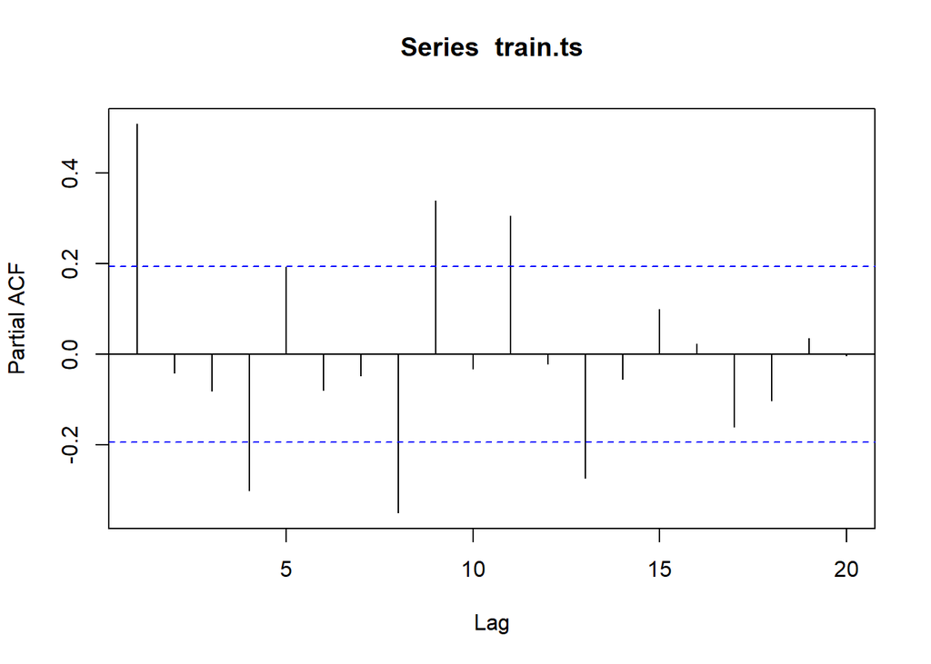

```r
pacf(train.ts)
```

Berdasarkan plot tersebut, terlihat bahwa plot PACF cenderung *cuts off* pada lag pertama, sehingga jika plot ACF dianggap *tails off*, maka model tentatifnya adalah ARIMA(1,0,0).

### Plot ACF & PACF secara bersamaan

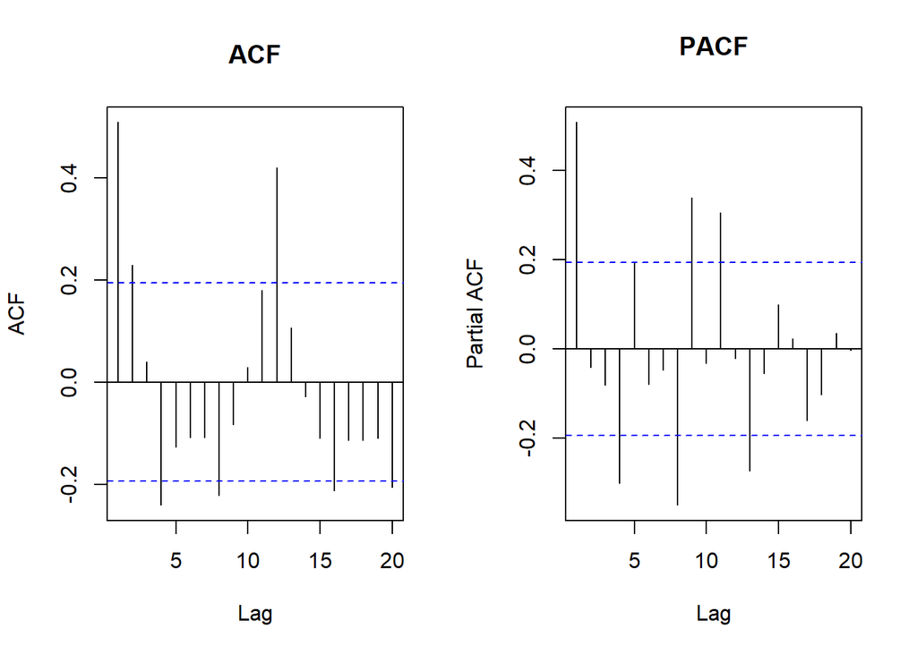

```r
par(mfrow = c(1,2))
acf(train.ts, main = "ACF", lag.max=20) #ARIMA(0,0,2)
pacf(train.ts, main = "PACF", lag.max=20) #ARIMA(1,0,0)
```

```r
par(mfrow = c(1,1))
```

Selanjutnya, selain dengan plot ACF dan PACF, penentuan spesifikasi model dapat dilakukan dengan *Extended ACF* (EACF), yakni dengan cara berikut ini.

### Plot EACF

```r
eacf(train.ts)
```

```
## AR/MA
##   0 1 2 3 4 5 6 7 8 9 10 11 12 13
## 0 x x o x o o o x o o o  x  o  o
## 1 o o o x o o o x o o o  x  o  o
## 2 x o x x o o o x o o o  x  x  o
## 3 x o x x o o o o o o o  x  o  o
## 4 x o o x o o o x o o o  x  o  x
## 5 x o o x o o o x o o o  x  o  o
## 6 x o o x x o o x o o o  o  x  o
## 7 o o x x x o x o o o o  o  o  o
```

Identifikasi model menggunakan plot EACF dilakukan dengan melihat ujung segitiga pada pola segitiga nol. Dengan menggunakan plot EACF, dapat diambil beberapa model tentatif yakni ARIMA (1,0,2).

## Pendugaan Parameter Model Tentatif

Selanjutnya akan dilakukan pendugaan parameter ketiga model ARIMA yang terbentuk sebelumnya. Pendugaan dilakukan dengan fungsi Arima() yang dilanjutkan dengan melihat nilai AIC pada ringkasan data serta melihat signifikansi parameter.

### ARIMA(0,0,2)

```r
model1.da=Arima(train.ts, order=c(0,0,2),method="ML")
summary(model1.da) #AIC=749.4
```

```
## Series: train.ts
## ARIMA(0,0,2) with non-zero mean
##
## Coefficients:
##          ma1     ma2     mean
##       0.4934  0.1087  47.8824
## s.e.  0.1413  0.2008   1.4460
##
## sigma^2 = 86.33:  log likelihood = -370.7
## AIC=749.4   AICc=749.81   BIC=759.9
##
## Training set error measures:
##                        ME     RMSE      MAE       MPE     MAPE     MASE
## Training set -0.009944575 9.153886 6.357818 -3.274752 13.11602 1.055526
##                    ACF1
## Training set 0.03693871
```

```r
lmtest::coeftest(model1.da) #ma2 tidak signifikan
```

```
##
## z test of coefficients:
##
##           Estimate Std. Error z value  Pr(>|z|)
## ma1        0.49342    0.14128  3.4925 0.0004785 ***
## ma2        0.10873    0.20076  0.5416 0.5881055
## intercept 47.88235    1.44602 33.1133 < 2.2e-16 ***
## ---
## Signif. codes:  0 '***' 0.001 '**' 0.01 '*' 0.05 '.' 0.1 ' ' 1
```

### ARIMA(1,0,0)

```r
model2.da=Arima(train.ts, order=c(1,0,0),method="ML")
summary(model2.da) #AIC=745.18
```

```
## Series: train.ts
## ARIMA(1,0,0) with non-zero mean
##
## Coefficients:
##          ar1     mean
##       0.5040  47.8787
## s.e.  0.0846   1.7893
##
## sigma^2 = 83.59:  log likelihood = -369.59
## AIC=745.18   AICc=745.42   BIC=753.05
##
## Training set error measures:
##                       ME     RMSE      MAE       MPE     MAPE     MASE
## Training set -0.01347458 9.052575 6.184157 -3.117315 12.74293 1.026695
##                    ACF1
## Training set 0.02529143
```

```r
lmtest::coeftest(model2.da) #seluruh parameter signifikan
```

```
##
## z test of coefficients:
##
##            Estimate Std. Error z value  Pr(>|z|)
## ar1        0.503972   0.084562  5.9598 2.526e-09 ***
## intercept 47.878715   1.789299 26.7584 < 2.2e-16 ***
## ---
## Signif. codes:  0 '***' 0.001 '**' 0.01 '*' 0.05 '.' 0.1 ' ' 1
```

### ARIMA(1,0,2)

```r
model3.da=Arima(train.ts, order=c(1,0,2),method="ML")
summary(model3.da) #AIC=748.83
```

```
## Series: train.ts
## ARIMA(1,0,2) with non-zero mean
##
## Coefficients:
##         ar1     ma1     ma2     mean
##       0.398  0.0963  0.1045  47.8963
## s.e.  0.197  0.1836  0.2173   1.7692
##
## sigma^2 = 84.99:  log likelihood = -369.42
## AIC=748.83   AICc=749.46   BIC=761.96
##
## Training set error measures:
##                       ME     RMSE      MAE       MPE     MAPE     MASE
## Training set -0.01635218 9.036576 6.104552 -3.096649 12.56736 1.013479
##                    ACF1
## Training set 0.01842366
```

```r
lmtest::coeftest(model3.da) #ma1, ma2, tidak signifikan
```

```
##
## z test of coefficients:
##
##            Estimate Std. Error z value Pr(>|z|)
## ar1        0.398006   0.196977  2.0206  0.04332 *
## ma1        0.096269   0.183565  0.5244  0.59997
## ma2        0.104482   0.217308  0.4808  0.63066
## intercept 47.896289   1.769216 27.0720  < 2e-16 ***
## ---
## Signif. codes:  0 '***' 0.001 '**' 0.01 '*' 0.05 '.' 0.1 ' ' 1
```

Berdasarkan pendugaan parameter di atas, nilai AIC terkecil dimiliki oleh model ARIMA(1,0,0) atau AR(1) serta parameter model tersebut juga seluruhnya signifikan sehingga model yang dipilih adalah model ARIMA(1,0,0).

## Analisis Sisaan

Model terbaik hasil identifikasi kemudian akan diperiksa asumsi sisaannya. Sisaan model ARIMA harus memenuhi asumsi normalitas, kebebasan sisaan, serta kehomogenan ragam. Diagnostik model dilakukan secara eksplorasi dan uji formal.

### Eksplorasi Sisaan

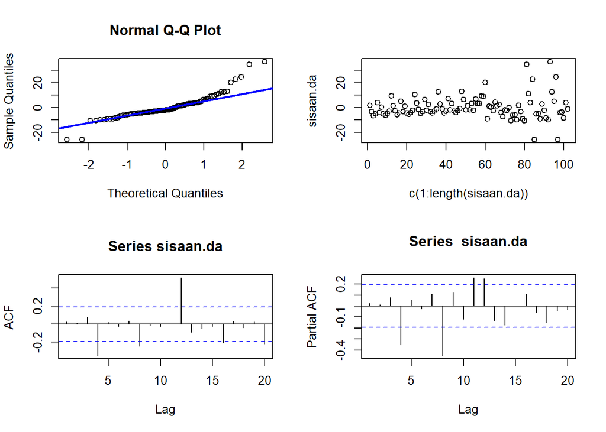

```r
#Eksplorasi
sisaan.da <- model2.da$residuals
par(mfrow=c(2,2))
qqnorm(sisaan.da)
qqline(sisaan.da, col = "blue", lwd = 2)
plot(c(1:length(sisaan.da)),sisaan.da)
acf(sisaan.da)
pacf(sisaan.da)
```

```r
par(mfrow = c(1,1))
```

Berdasarkan plot kuantil-kuantil QQplot normal, secara eksplorasi ditunjukkan sisaan tidak menyebar normal ditandai dengan titik-titik yang cenderung tidak mengikuti garis $45^\circ$. Kemudian dapat dilihat juga lebar pita sisaan yang cenderung tidak sama menandakan bahwa sisaan memiliki ragam yang heterogen. Plot ACF dan PACF sisaan ARIMA(1,0,0) signifikan pada lag tertentu sehingga menandakan sisaan tidak saling bebas. Kondisi ini akan diuji lebih lanjut dengan uji formal.

### Uji Formal

```r
#1) Sisaan Menyebar Normal
ks.test(sisaan.da,"pnorm")
```

```
##
##  Asymptotic one-sample Kolmogorov-Smirnov test
##
## data:  sisaan.da
## D = 0.50095, p-value < 2.2e-16
## alternative hypothesis: two-sided
```

Uji formal yang akan digunakan adalah uji Kolmogorov-Smirnov (KS). Hipotesis pada uji KS adalah sebagai berikut.

$H_0$: Sisaan menyebar normal

$H_1$: Sisaan tidak menyebar normal

Berdasarkan uji tersebut, didapatkan nilai p-value kurang dari $2.2\times 10^{-16}$ yang kurang dari taraf nyata 5% sehingga tolak $H_0$ dan menandakan bahwa sisaan tidak menyebar normal. Hal ini sesuai dengan hasil eksplorasi mengunakan plot kuantil-kuantil normal.

```r
#2) Sisaan saling bebas/tidak ada autokorelasi
Box.test(sisaan.da, type = "Ljung")
```

```
##
##  Box-Ljung test
##
## data:  sisaan.da
## X-squared = 0.067183, df = 1, p-value = 0.7955
```

Selanjutnya dilakukan uji formal untuk asumsi kebebasan sisaan menggunakan uji Ljung-Box. Hipotesis yang digunakan adalah sebagai berikut.

$H_0$: Sisaan saling bebas

$H_1$: Sisaan tidak saling bebas

Berdasarkan uji tersebut, didapatkan nilai p-value sebesar 0.7955 yang lebih besar dari taraf nyata 5% sehingga tak tolak $H_0$ dan menandakan sisaan saling bebas. Hal ini berbeda dengan eksplorasi.

```r
#3) Sisaan homogen
Box.test((sisaan.da)^2, type = "Ljung")
```

```
##
##  Box-Ljung test
##
## data:  (sisaan.da)^2
## X-squared = 3.8272, df = 1, p-value = 0.05043
```

Hipotesis yang digunakan untuk uji kehomogenan ragam adalah sebagai berikut.

$H_0$: Ragam sisaan homogen

$H_1$: Ragam sisaan tidak homogen

Berdasarkan uji Ljung-Box terhadap sisaan kuadrat tersebut, didapatkan nilai p-value sebesar 0.05043 yang lebih dari taraf nyata 5% sehingga tak tolak $H_0$ dan menandakan ragam sisaan homogen.

```r
#4) Nilai tengah sisaan sama dengan nol
t.test(sisaan.da, mu = 0, conf.level = 0.95)
```

```
##
##  One Sample t-test
##
## data:  sisaan.da
## t = -0.014959, df = 101, p-value = 0.9881
## alternative hypothesis: true mean is not equal to 0
## 95 percent confidence interval:
##  -1.800348  1.773399
## sample estimates:
##   mean of x
## -0.01347458
```

Terkahir, dilakukan uji-t, akan dicek apakah nilai tengah sisaan sama dengan nol. Hipotesis yang diujikan adalah sebagai berikut.

$H_0$: Nilai tengah sisaan sama dengan 0

$H_1$: Nilai tengah sisaan tidak sama dengan 0

Berdasarkan uji tersebut diperoleh nilai p-value sebesar 0.9881 yang lebih besar dari taraf nyata 5% sehingga tak tolak $H_0$, sehingga dapat dikatakan bahwa nilai tengah sisaan sama dengan nol.

## Overfitting

Tahap selanjutnya adalah *overfitting* yang dilakukan dengan menaikkan orde AR(p) dan MA(q) dari model ARIMA(1,0,0) untuk melihat apakah terdapat model lain yang lebih baik dari model saat ini. Kandidat model *overfitting* adalah ARIMA(2,0,0) dan ARIMA(1,0,1).

```r
#---OVERFITTING---#
model1a.ma2=Arima(train.ts, order=c(2,0,0),method="ML")
summary(model1a.ma2) #747.01
```

```
## Series: train.ts
## ARIMA(2,0,0) with non-zero mean
##
## Coefficients:
##          ar1      ar2     mean
##       0.5247  -0.0403  47.8815
## s.e.  0.0984   0.0981   1.7224
##
## sigma^2 = 84.29:  log likelihood = -369.5
## AIC=747.01   AICc=747.42   BIC=757.51
##
## Training set error measures:
##                       ME     RMSE      MAE       MPE     MAPE     MASE
## Training set -0.01302247 9.044922 6.172569 -3.110493 12.71932 1.024771
##                     ACF1
## Training set 0.001530523
```

```r
lmtest::coeftest(model1a.ma2) #ar2 tidak signifikan
```

```
##
## z test of coefficients:
##
##            Estimate Std. Error z value  Pr(>|z|)
## ar1        0.524674   0.098399  5.3321 9.707e-08 ***
## ar2       -0.040294   0.098105 -0.4107    0.6813
## intercept 47.881533   1.722445 27.7986 < 2.2e-16 ***
## ---
## Signif. codes:  0 '***' 0.001 '**' 0.01 '*' 0.05 '.' 0.1 ' ' 1
```

```r
model1b.ma2=Arima(train.ts, order=c(1,0,1),method="ML")
summary(model1b.ma2) #747.04
```

```
## Series: train.ts
## ARIMA(1,0,1) with non-zero mean
##
## Coefficients:
##          ar1     ma1     mean
##       0.4548  0.0667  47.8805
## s.e.  0.1677  0.1872   1.7372
##
## sigma^2 = 84.32:  log likelihood = -369.52
## AIC=747.04   AICc=747.45   BIC=757.54
##
## Training set error measures:
##                       ME     RMSE      MAE       MPE    MAPE     MASE
## Training set -0.01316234 9.046408 6.176944 -3.112022 12.7286 1.025497
##                     ACF1
## Training set 0.005980522
```

```r
lmtest::coeftest(model1b.ma2) #ma1 tidak signifikan
```

```
##
## z test of coefficients:
##
##            Estimate Std. Error z value  Pr(>|z|)
## ar1        0.454751   0.167714  2.7115  0.006698 **
## ma1        0.066695   0.187208  0.3563  0.721644
## intercept 47.880546   1.737157 27.5626 < 2.2e-16 ***
## ---
## Signif. codes:  0 '***' 0.001 '**' 0.01 '*' 0.05 '.' 0.1 ' ' 1
```

Sehingga model yang dipilih adalah model awal, yaitu ARIMA(1,0,0).

## Peramalan

Peramalan dilakukan menggunakan fungsi forecast(). Berikut akan diramal untuk 18 bulan ke depan.

```r
#---FORECAST---#
ramalan.da <- forecast::forecast(model2.da, h = 18)
ramalan.da
```

```
##     Point Forecast    Lo 80    Hi 80    Lo 95    Hi 95
## 103       46.60935 34.89257 58.32613 28.69008 64.52862
## 104       47.23899 34.11835 60.35963 27.17270 67.30528
## 105       47.55631 34.10242 61.01021 26.98035 68.13227
## 106       47.71623 34.17900 61.25347 27.01282 68.41964
## 107       47.79683 34.23851 61.35515 27.06117 68.53249
## 108       47.83745 34.27378 61.40111 27.09361 68.58129
## 109       47.85792 34.29289 61.42294 27.11200 68.60383
## 110       47.86823 34.30286 61.43360 27.12179 68.61468
## 111       47.87343 34.30797 61.43889 27.12685 68.62001
## 112       47.87605 34.31057 61.44153 27.12944 68.62267
## 113       47.87737 34.31189 61.44286 27.13075 68.62399
## 114       47.87804 34.31255 61.44353 27.13142 68.62466
## 115       47.87837 34.31289 61.44386 27.13175 68.62500
## 116       47.87854 34.31306 61.44403 27.13192 68.62517
## 117       47.87863 34.31314 61.44412 27.13200 68.62525
## 118       47.87867 34.31318 61.44416 27.13205 68.62530
## 119       47.87869 34.31321 61.44418 27.13207 68.62532
## 120       47.87870 34.31322 61.44419 27.13208 68.62533
```

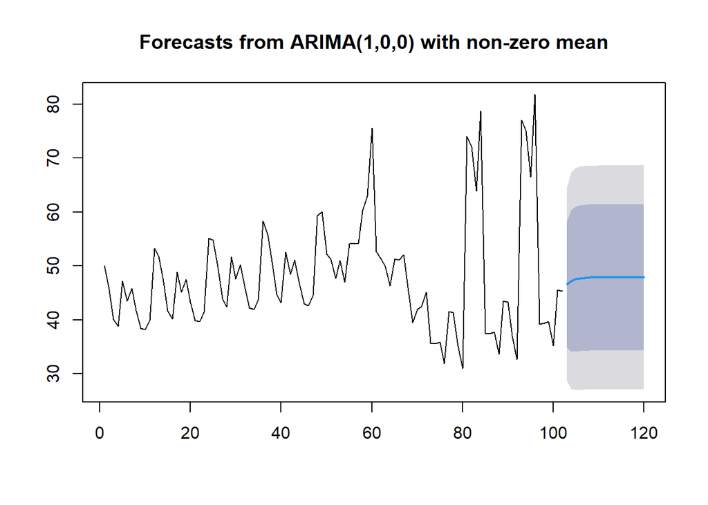

```r
data.ramalan.da <- ramalan.da$mean
plot(ramalan.da)
```

Berdasarkan hasil plot ramalan di atas, dapat dilihat bahwa ramalan ARIMA(1,0,0) meningkat di awal periode dan stabil hingga akhir periode. Selanjutnya, dapat dicari nilai akurasi antara hasil ramalan dengan data uji sebagai berikut.

```r
perbandingan.da<-matrix(data=c(test.ts, data.ramalan.da), nrow = 18, ncol = 2)
colnames(perbandingan.da)<-c("Aktual","Hasil Forecast")
perbandingan.da
```

```
##       Aktual Hasil Forecast
##  [1,]  38.87       46.60935
##  [2,]  34.32       47.23899
##  [3,]  80.08       47.55631
##  [4,]  78.15       47.71623
##  [5,]  69.33       47.79683
##  [6,]  85.09       47.83745
##  [7,]  40.16       47.85792
##  [8,]  40.01       47.86823
##  [9,]  39.15       47.87343
## [10,]  36.73       47.87605
## [11,]  42.75       47.87737
## [12,]  42.95       47.87804
## [13,]  40.28       47.87837
## [14,]  35.32       47.87854
## [15,]  49.37       47.87863
## [16,]  51.21       47.87867
## [17,]  48.77       47.87869
## [18,]  52.39       47.87870
```

```r
accuracy(ts(data.ramalan.da), test.ts)
```

```
##                ME     RMSE      MAE       MPE     MAPE      ACF1 Theil's U
## Test set 2.537343 16.13153 12.12582 -2.917668 22.29105 0.4694731 0.8912883
```

Diperoleh nilai MAPE (salah satu *accuracy measures)* sebesar 22.29 persen, dimana kurang baik karena termasuk cukup besar. Akan lebih baik apabila diperoleh nilai MAPE yang kurang dari 10%. Salah satu saran yang dapat diberikan adalah mencoba menangani ketidakstasioneran pada ragam yang sebelumnya dijumpai, dengan cara melakukan transformasi menggunakan box-cox, dengan harapan dapat memperbaikki sehingga dapat memberikan model dengan hasil yang lebih akurat.